# 日期和時間

黃孟婷

Mar 18, 2019

# 簡介

本章將介紹如何使用R中的日期和時間。雖然這是一個貼近生活的主題，但是當我們越了解卻發現這裡的問題是複雜的。以下三個簡單的問題讓大家思考一下：

1.每年都有365天嗎？  
2.每天都有24小時嗎？  
3.每分鐘都有60秒嗎？

大家都知道不是每年都有365天，但是你知道一年是否為閏年的確切規則嗎？有些人可能不記得世界上很多地方都使用夏令時（DST），所以有些時候一天有23個小時，有些則有25個。而有些人可能不知道有些時間有61秒因為由於地球的自轉速度逐漸減慢，所以偶爾會增加閏秒。

# 套件

本章將重點介紹lubridate套件，它可以更容易地處理日期和時間。另外，我們需要nycflights13套件內的航班資料來作練習。(參考資料[1])

```r
library(tidyverse)
library(magrittr)
library(lubridate)
library(nycflights13)
library(dplyr)
```

# 產生日期/時間的方式

有幾種類型的日期/時間數據可以引用即時時間：

1.日期。Tibbles將此顯示成date。  
2.在一天之內的時間。Tibbles將此顯示成time。  
3.日期時間指的是一個日期加上時間。Tibbles將此顯示成dttm。  
4.其他R顯示成POSIXct。

我們從最常見最簡單的數據類型開始介紹：

要獲取當前日期或日期時間，可以使用today()或now()。另外，可由am(),pm()判斷時間是早上或是下午：

```r
today()
```

```
## [1] "2019-05-24"
```

```r
now()
```

```
## [1] "2019-05-24 19:05:41 CST"
```

```r
am(now())
```

```
## [1] FALSE
```

```r
pm(now())
```

```
## [1] TRUE
```

建立日期/時間的三種方法：

1.從一個字串。  
2.從個別日期時間元素。  
3.從現有的日期/時間對象。

## 字串

日期/時間資料通常以字串形式出現，我們可利用lubridate創造。創造它們時，請確定日期中出現的年、月和日的順序，然後按相同的順序排列“y”,“m”和“d”。例如：

```r
ymd("2017-03-11")
```

```
## [1] "2017-03-11"
```

```r
mdy("March 11st, 2017")
```

```
## [1] "2017-03-11"
```

```r
dmy("11-Mar-2017")
```

```
## [1] "2017-03-11"
```

不帶引號的數字也有相同的功能，這是最簡潔方法。

```r
ymd(20170311)
```

```
## [1] "2017-03-11"
```

ymd()等創造日期的函數，若是要創建日期和時間，請在函數的名稱中添加“_“以及”h“,”m“和”s“中，需要創造的時刻：

```r
ymd_hms("2017-03-11 20:15:59")
```

```
## [1] "2017-03-11 20:15:59 UTC"
```

```r
mdy_hm("03/11/2017 08:01")
```

```
## [1] "2017-03-11 08:01:00 UTC"
```

還可以通過提供時區強制從日期創建日期時間：

```r
ymd(20170311, tz = "UTC")
```

```
## [1] "2017-03-11 UTC"
```

## 從個別日期時間元素

有時候，散落在各行的元素可相結合，並創造一個日期時間。以下我們討論航班資料的例子：

首先，看一下資料的樣貌和變數，並將資料轉成data frame模式

```r
flights %>%
  View()
flights = as.data.frame(flights)
```

要從此類創建日期/時間，請使用make_date()創建日期或make_datetime()創建日期時間：

```r
flights_datetime <- flights %>%
  select(year, month, day, hour, minute) %>%
  mutate(departure = make_datetime(year, month, day, hour, minute))
```

由於dep_time,arr_time,sched_dep_time,sched_arr_time 等的原始表示方式是三或四位數字，最後兩位代表分鐘，我們在 make_datetime_100 函式中先將小時與分鐘切開，才進行轉換。

提醒:  
1.%/%:整數除法; %%:餘數除法  
2.在filter()函數中我們輸入要篩選的資料框  
3.ends_with選擇結尾是delay或time的變數

```r
make_datetime_100 <- function(year, month, day, time) {
  make_datetime(year, month, day, time %/% 100, time %% 100)
}
flights_dt <- flights %>%
  filter(!is.na(dep_time), !is.na(arr_time)) %>%
  mutate(
    dep_time = make_datetime_100(year, month, day, dep_time),
    arr_time = make_datetime_100(year, month, day, arr_time),
    sched_dep_time = make_datetime_100(year, month, day, sched_dep_time),
    sched_arr_time = make_datetime_100(year, month, day, sched_arr_time)
  ) %>%
  select(origin, dest, ends_with("delay"), ends_with("time"))
```

有了這些數據，我們可以看到全年的出發時間分佈：

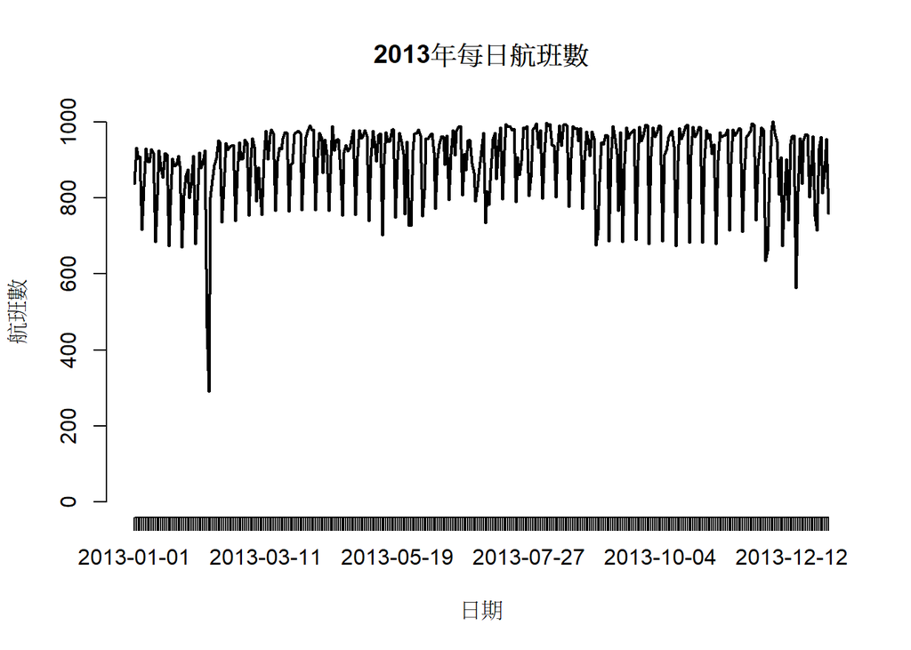

```r
freq <- flights_dt %>%
  mutate(departure = make_date(year(dep_time), month(dep_time), day(dep_time)))%>%
  select(departure,dep_time)

plot(table(freq$departure),type = "l",main = "2013年每日航班數",xlab = "日期",ylab = "航班數")
```

或者在一天之內(下圖顯示2013/01/01的航班)：

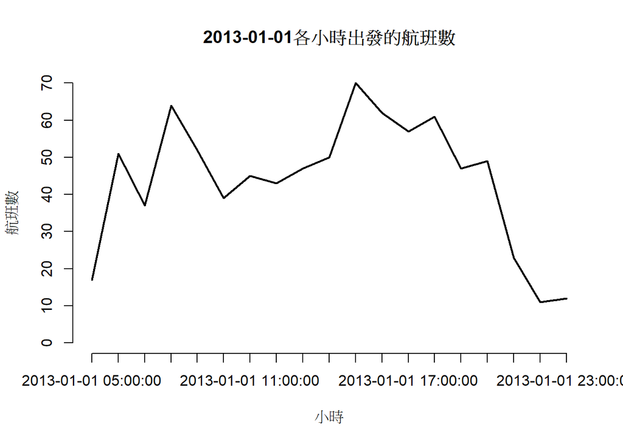

```r
flight0101 <- freq %>%
  filter(departure<"2013-01-02") %>%
  mutate(freq_hour = make_datetime(year(dep_time),month(dep_time),day(dep_time),hour(dep_time)))%>%
  select(freq_hour)

plot(table(flight0101),type = "l",xlab = "小時",main = "2013-01-01各小時出發的航班數",ylab="航班數")
```

## 來自其他類型

使用者可能希望在日期時間和日期之間做轉換。這就是as_datetime()和as_date()的工作：

```r
today()
```

```
## [1] "2019-05-24"
```

```r
now()
```

```
## [1] "2019-05-24 19:06:14 CST"
```

```r
as_datetime(today())
```

```
## [1] "2019-05-24 UTC"
```

```r
as_date(now())
```

```
## [1] "2019-05-24"
```

有時使用者會從1970-01-01的“Unix Epoch”獲得數字移動的日期/時間。  
如果移動量以秒為單位，請使用as_datetime();  
如果是幾天，請使用as_date()。  
註：UNIX是從UTC時間1970年01月01日0時0分0秒至今，不考慮閏秒

```r
as_datetime(60 * 60 * 10)
```

```
## [1] "1970-01-01 10:00:00 UTC"
```

```r
as_date(365 * 10 + 2)
```

```
## [1] "1980-01-01"
```

# 日期時間元素

本節將介紹取得或設置各個元素的功能。 下一節將介紹算術如何使用日期時間。

## 取得元素

取得日期的各個部分與存取函數:  
year(), month(), mday()(一個月的第幾天), qday()(一季的第幾天,一至三月是一季以此類推), yday()(一年中的第幾天), wday()(一週的第幾天，星期日是第一天), hour(), minute()和second()

```r
datetime <- ymd_hms("2016-06-08 12:34:56")

year(datetime)
```

```
## [1] 2016
```

```r
month(datetime)
```

```
## [1] 6
```

```r
mday(datetime)
```

```
## [1] 8
```

```r
qday(datetime)
```

```
## [1] 69
```

```r
yday(datetime)
```

```
## [1] 160
```

```r
wday(datetime)
```

```
## [1] 4
```

month()，wday()可以設置label = TRUE指的是回傳月份或星期幾的縮寫名稱。設置abbr = FALSE為回傳全名。  
小提醒:days(-4:2)表示從前四天列到後兩天

```r
month(datetime, label = TRUE)
```

```
## [1] 六月
## 12 Levels: 一月 < 二月 < 三月 < 四月 < 五月 < 六月 < 七月 < ... < 十二月
```

```r
wday(datetime, label = TRUE, abbr = FALSE)
```

```
## [1] 星期三
## 7 Levels: 星期日 < 星期一 < 星期二 < 星期三 < 星期四 < ... < 星期六
```

```r
wday(datetime + days(-4:2), label = TRUE)
```

```
## [1] 週六 週日 週一 週二 週三 週四 週五
## Levels: 週日 < 週一 < 週二 < 週三 < 週四 < 週五 < 週六
```

我們可以wday()看到有更多航班在工作日起飛：

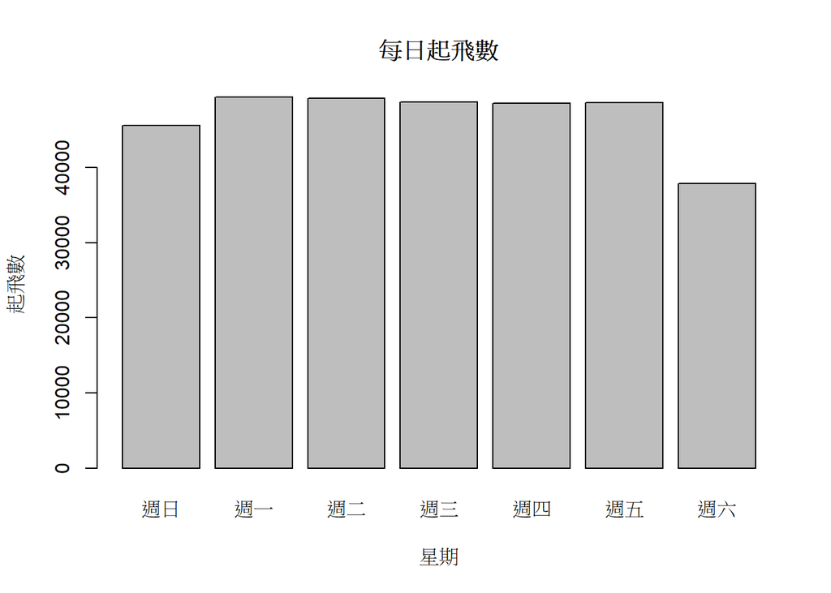

```r
flights_week<-
  flights_dt %>%
  mutate(wday = wday(dep_time, label = TRUE)) %>%
  select(wday)

plot(flights_week,main="每日起飛數", xlab = "星期", ylab = "起飛數")
```

## 捨入(Rounding)

產生時間元素的另一種方法是使用 floor_date(), round_date() 和 ceiling_date()。將日期四捨五入到附近的時間單位，每個函數都會對日期向量進行調整，然後將單位的名稱向下捨入，向上捨入或四捨五入。

```r
datetime = ymd_hms("2016-05-15 11:04:56")
floor_date(datetime,"year")
```

```
## [1] "2016-01-01 UTC"
```

```r
ceiling_date(datetime,"month")
```

```
## [1] "2016-06-01 UTC"
```

```r
round_date(datetime,"day")
```

```
## [1] "2016-05-15 UTC"
```

2013-01-01那天每小時內有多少飛機起飛?

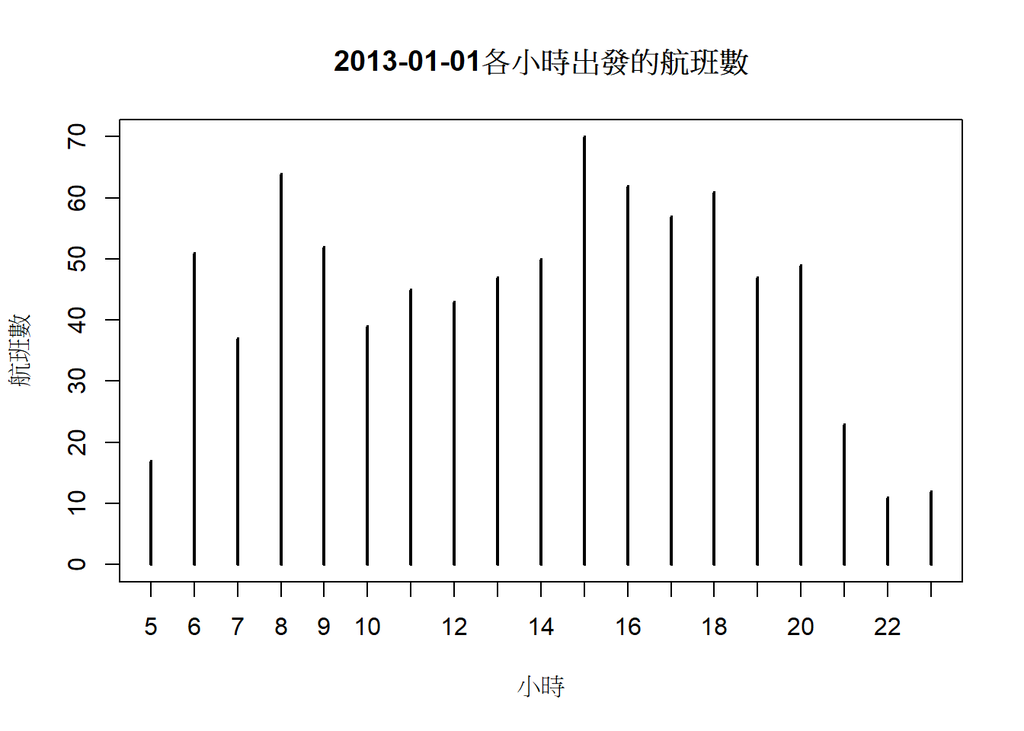

```r
flight_count <- freq %>%
  filter(departure<"2013-01-02")%>%
  mutate(hour = hour(floor_date(dep_time, "hour"))) %>%
  select(hour)

plot(table(flight_count),xlab = "小時",main = "2013-01-01各小時出發的航班數",ylab="航班數")
```

## 設定時間元素

設定或更新日期/時間的元素：

```r
datetime <- ymd_hms("2017-07-08 12:35:56")

year(datetime) <- 2020
month(datetime) <- 01
hour(datetime) <- hour(datetime) + 1
datetime
```

```
## [1] "2020-01-08 13:35:56 UTC"
```

利用update()一次更新多個元素。

```r
update(datetime, year = 2020, month = 2, mday = 2, hour = 2)
```

```
## [1] "2020-02-02 02:35:56 UTC"
```

```r
ymd("2015-02-01") %>%
  update(mday = 30)
```

```
## [1] "2015-03-02"
```

```r
ymd("2015-02-01") %>%
  update(hour = 400)
```

```
## [1] "2015-02-17 16:00:00 UTC"
```

用update()改變所有日期，可顯示一年中24小時的航班分佈

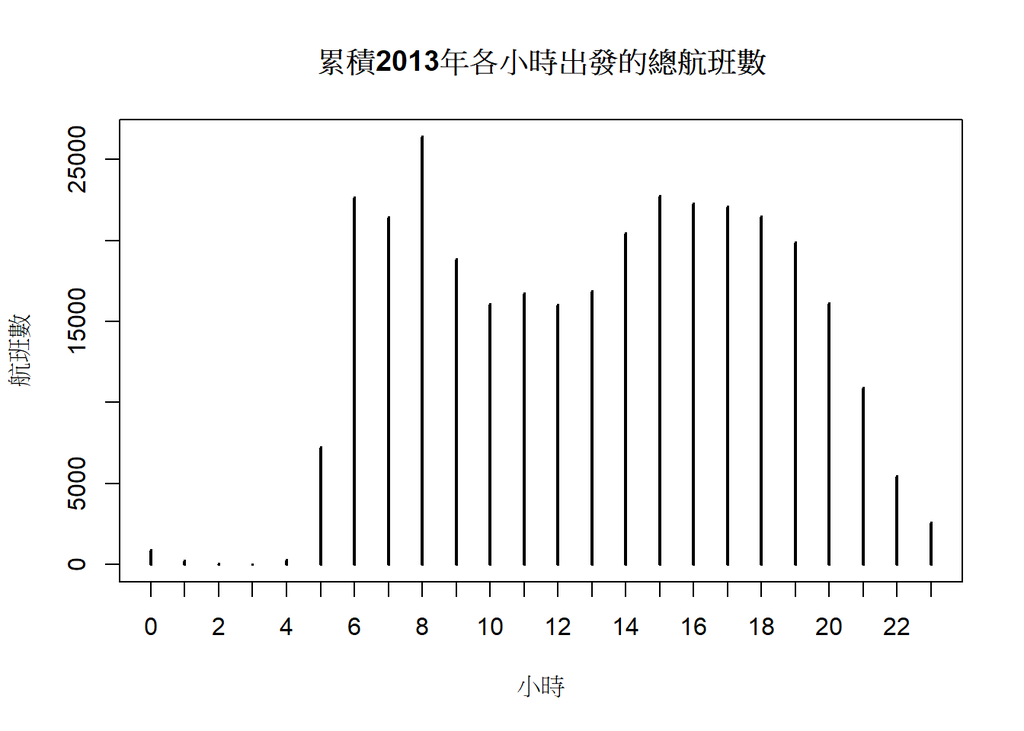

```r
flight_count2 <-
flights_dt %>%
  mutate(dep_hour = update(dep_time, yday = 1),
         hour = hour(floor_date(dep_hour, "hour"))) %>%
  select(hour)
plot(table(flight_count2),main = "累積2013年各小時出發的總航班數",xlab = "小時", ylab = "航班數")
```

# 時間間隔(Time spans)

接下來，我們將了解日期算法的工作原理，包括減法，加法和除法。在此過程中討論三種代表時間間隔的方式：  
1.持續時間(duration)，表示精確的秒數。  
2.時期(period)，代表人會使用的單位，如週和月。  
3.間隔(interval)，代表起點和終點。

## 持續時間(duration)

欲知Emily今年幾歲？

```r
h_age <- today() - ymd(19961014)
h_age
```

```
## Time difference of 8257 days
```

lubridate提供了一種總是使用秒的替代方案：持續時間。

```r
as.duration(h_age)
```

```
## [1] "713404800s (~22.61 years)"
```

構造持續時間可使用以下方便的函數：

```r
dseconds(15)
```

```
## [1] "15s"
```

```r
dminutes(10)
```

```
## [1] "600s (~10 minutes)"
```

```r
dhours(c(12, 24))
```

```
## [1] "43200s (~12 hours)" "86400s (~1 days)"
```

```r
ddays(0:5)
```

```
## [1] "0s"                "86400s (~1 days)"  "172800s (~2 days)"
## [4] "259200s (~3 days)" "345600s (~4 days)" "432000s (~5 days)"
```

```r
dweeks(3)
```

```
## [1] "1814400s (~3 weeks)"
```

```r
dyears(1)
```

```
## [1] "31536000s (~52.14 weeks)"
```

持續時間始終以秒為單位記錄時間長度。通過將分鐘，小時，天，週和年轉換為標準速率(一分鐘60秒，一小時60分鐘，一天24小時，一週七天，一年365天)。

持續時間可以相加和相乘：

```r
3 * dyears(1)
```

```
## [1] "94608000s (~3 years)"
```

```r
dyears(1) + dweeks(12) + dhours(10)
```

```
## [1] "38829600s (~1.23 years)"
```

```r
tomorrow <- today() + ddays(1)
last_year <- today() - dyears(1)
tomorrow
```

```
## [1] "2019-05-25"
```

```r
last_year
```

```
## [1] "2018-05-24"
```

但是，因為持續時間代表精確的秒數，有時使用者可能會得到意外的結果： tz代表的是時區，“America/New_York”代表美國紐約時間，“Asia/Taipei”代表台灣時間。詳見後面章節。

```r
one_pm_NY <- ymd_hms("2016-03-12 13:00:00", tz = "America/New_York")
one_pm_NY + ddays(1)
```

```
## [1] "2016-03-13 14:00:00 EDT"
```

```r
one_pm_TW <- ymd_hms("2016-03-12 13:00:00", tz = "Asia/Taipei")
one_pm_TW + ddays(1)
```

```
## [1] "2016-03-13 13:00:00 CST"
```

# 時期(period)

為了解決前面的問題，lubridate提供了時期的型態。時期是時間長度，但在幾秒鐘內沒有固定的長度，而是與人們日常的時間一起運行。觀察以下兩個例子，時期的型態會和我們日常直覺的時間相同。

```r
one_pm_NY
```

```
## [1] "2016-03-12 13:00:00 EST"
```

```r
one_pm_NY + ddays(1)
```

```
## [1] "2016-03-13 14:00:00 EDT"
```

```r
one_pm_NY + days(1)
```

```
## [1] "2016-03-13 13:00:00 EDT"
```

提醒:2016年為閏年

```r
ymd("2016-01-01") + dyears(1)
```

```
## [1] "2016-12-31"
```

```r
ymd("2016-01-01") + years(1)
```

```
## [1] "2017-01-01"
```

將任何間隔轉換為特定的時期： as.period()。

```r
as.period(h_age)
```

```
## [1] "8257d 0H 0M 0S"
```

```r
leap <- interval(ymd("2016-01-01"), ymd_hms("2017-02-02 01:01:01"))
as.period(leap, unit = "years")
```

```
## [1] "1y 1m 1d 1H 1M 1S"
```

```r
as.period(leap, unit = "months")
```

```
## [1] "13m 1d 1H 1M 1S"
```

```r
as.period(leap, unit = "days")
```

```
## [1] "398d 1H 1M 1S"
```

```r
as.period(leap, unit = "hours")
```

```
## [1] "9553H 1M 1S"
```

構造時期可使用以下方便的函數：

```r
seconds(15)
```

```
## [1] "15S"
```

```r
minutes(10)
```

```
## [1] "10M 0S"
```

```r
hours(c(12, 24))
```

```
## [1] "12H 0M 0S" "24H 0M 0S"
```

```r
days(7)
```

```
## [1] "7d 0H 0M 0S"
```

```r
months(1:6)
```

```
## [1] "1m 0d 0H 0M 0S" "2m 0d 0H 0M 0S" "3m 0d 0H 0M 0S" "4m 0d 0H 0M 0S"
## [5] "5m 0d 0H 0M 0S" "6m 0d 0H 0M 0S"
```

```r
weeks(3)
```

```
## [1] "21d 0H 0M 0S"
```

```r
years(1)
```

```
## [1] "1y 0m 0d 0H 0M 0S"
```

也可以對時期做加或乘的運算：

```r
10 * (months(6) + days(1))
```

```
## [1] "60m 10d 0H 0M 0S"
```

```r
days(50) + hours(25) + minutes(10)
```

```
## [1] "50d 25H 10M 0S"
```

```r
meeting <- Sys.Date()
meetings <- meeting + weeks(0:5)
meetings
```

```
## [1] "2019-05-24" "2019-05-31" "2019-06-07" "2019-06-14" "2019-06-21"
## [6] "2019-06-28"
```

以下的例子顯示有些飛機在離開紐約市之前似乎已到達目的地。我們將使用時期更正航班日期相關的奇怪現象。

```r
flights_dt %>%
  filter(arr_time < dep_time)%>%
  head(10)
```

```
##    origin dest dep_delay arr_delay            dep_time      sched_dep_time
## 1     EWR  BQN         9        -4 2013-01-01 19:29:00 2013-01-01 19:20:00
## 2     JFK  DFW        59        NA 2013-01-01 19:39:00 2013-01-01 18:40:00
## 3     EWR  TPA        -2         9 2013-01-01 20:58:00 2013-01-01 21:00:00
## 4     EWR  SJU        -6       -12 2013-01-01 21:02:00 2013-01-01 21:08:00
## 5     EWR  SFO        11       -14 2013-01-01 21:08:00 2013-01-01 20:57:00
## 6     LGA  FLL       -10        -2 2013-01-01 21:20:00 2013-01-01 21:30:00
## 7     EWR  MCO        41        43 2013-01-01 21:21:00 2013-01-01 20:40:00
## 8     JFK  LAX        -7       -24 2013-01-01 21:28:00 2013-01-01 21:35:00
## 9     EWR  FLL        49        28 2013-01-01 21:34:00 2013-01-01 20:45:00
## 10    EWR  FLL        -9       -14 2013-01-01 21:36:00 2013-01-01 21:45:00
##               arr_time      sched_arr_time air_time
## 1  2013-01-01 00:03:00 2013-01-01 00:07:00      192
## 2  2013-01-01 00:29:00 2013-01-01 21:51:00       NA
## 3  2013-01-01 00:08:00 2013-01-01 23:59:00      159
## 4  2013-01-01 01:46:00 2013-01-01 01:58:00      199
## 5  2013-01-01 00:25:00 2013-01-01 00:39:00      354
## 6  2013-01-01 00:16:00 2013-01-01 00:18:00      160
## 7  2013-01-01 00:06:00 2013-01-01 23:23:00      143
## 8  2013-01-01 00:26:00 2013-01-01 00:50:00      338
## 9  2013-01-01 00:20:00 2013-01-01 23:52:00      152
## 10 2013-01-01 00:25:00 2013-01-01 00:39:00      154
```

這些其實是隔夜航班。我們對出發和到達時間使用了相同的日期，但這些航班其實是在第二天到達。我們可以通過增加days(1)每個夜間航班的到達時間解決這個問題。 提醒：overnight 是T/F，overnight*1 後變1/0

```r
flights_dt <- flights_dt %>%
  mutate(
    overnight = arr_time < dep_time,
    arr_time = arr_time + days(overnight * 1),
    sched_arr_time = sched_arr_time + days(overnight * 1)
  )
```

現在我們所有的航班都遵守物理定律。

```r
flights_dt %>%
  filter(overnight, arr_time < dep_time)%>%
  head(10)
```

```
##  [1] origin         dest           dep_delay      arr_delay
##  [5] dep_time       sched_dep_time arr_time       sched_arr_time
##  [9] air_time       overnight
## <0 rows> (or 0-length row.names)
```

### 注意

dyears(1) / ddays(365)應該回傳的是顯而易見的：因為持續時間總是由幾秒錶示，一年的持續時間定義為365天的秒。

那麼years(1) / days(1)應該回傳什麼？如果這一年是2015年它應該返回365，但如果它是2016年，它應該返回366！不幸地是，lubridate沒有足夠的資訊給出一個明確的答案。它的作用是做出估計，並發出警告。

```r
years(1) / days(1)
```

```
## estimate only: convert to intervals for accuracy
```

```
## [1] 365.25
```

若要給lubridate足夠的資訊，可以透過明確的起迄時點，也就是以下要介紹的區間(interval)形式。

# 區間(interval)

有很多方式可以構造區間。 最簡單的方式是指定起迄時點：

```r
(today() %--% tomorrow)
```

```
## [1] 2019-05-24 UTC--2019-05-25 UTC
```

```r
interval(today() ,tomorrow)
```

```
## [1] 2019-05-24 UTC--2019-05-25 UTC
```

也可透過as.interval(x, start, …)，其中x:時間差異; start:時間起始點

```r
diff <- make_difftime(days = 2)
as.interval(diff, ymd("2011-08-10"))
```

```
## [1] 2011-08-10 UTC--2011-08-12 UTC
```

```r
dur <- duration(days = 10)
as.interval(dur, ymd("2011-08-10"))
```

```
## [1] 2011-08-10 UTC--2011-08-20 UTC
```

```r
per <- period(months = 3)
as.interval(per, ymd("2011-08-10"))
```

```
## [1] 2011-08-10 UTC--2011-11-10 UTC
```

```r
as.interval(365, ymd("2011-08-10"))
```

```
## [1] 2011-08-10 UTC--2012-08-09 UTC
```

討論兩區間的關係：  
1.一區間是否被另一區間完全涵蓋

```r
per <- period(months = 5)
interval1 = as.interval(per, ymd("2011-08-10"))
interval2 = as.interval(365, ymd("2011-09-10"))
interval1 %within% interval2
```

```
## [1] FALSE
```

2.兩區間是否重疊

```r
interval1 = as.interval(per, ymd("2011-08-10"))
interval2 = as.interval(365, ymd("2011-09-10"))
int_overlaps(interval1,interval2)
```

```
## [1] TRUE
```

## 小結

如何在持續時間，時期和區間之間做選擇？與往常一樣，選擇最簡單的數據結構來解決問題。如果使用者只關心物理時間，請用持續時間;如果使用者需要添加人類日常生活的時間，請使用一段時期;如果需要精確長度的持續時間，請使用區間。

## 補充

在時間計算時，由於日期數據的特殊性，如果我們需要得到每個月最後一天或第一天的日期數據，可使用%m+%和%m-%函數：

```r
jan31 <- ymd("2013-01-31")
jan31 + months(0:11)
```

```
##  [1] "2013-01-31" NA           "2013-03-31" NA           "2013-05-31"
##  [6] NA           "2013-07-31" "2013-08-31" NA           "2013-10-31"
## [11] NA           "2013-12-31"
```

```r
jan31 %m+% months(0:11)
```

```
##  [1] "2013-01-31" "2013-02-28" "2013-03-31" "2013-04-30" "2013-05-31"
##  [6] "2013-06-30" "2013-07-31" "2013-08-31" "2013-09-30" "2013-10-31"
## [11] "2013-11-30" "2013-12-31"
```

```r
floor_date(jan31, "month") %m-% months(0:11)
```

```
##  [1] "2013-01-01" "2012-12-01" "2012-11-01" "2012-10-01" "2012-09-01"
##  [6] "2012-08-01" "2012-07-01" "2012-06-01" "2012-05-01" "2012-04-01"
## [11] "2012-03-01" "2012-02-01"
```

或是利用函數，找出該月的最後一天

```r
last_day <- function(date) {
  ceiling_date(date, "month") - days(1)
}
last_day(today())
```

```
## [1] "2019-05-31"
```

# 時區

R使用國際標準IANA時區。這些使用一致的命名方案“/“，通常採用”州/城市“的形式。例如“America / New_York”，“Europe / Paris”和“Asia / Taipei”

Sys.timezone() 可以找出R認為使用者當前的時區：

```r
Sys.timezone()
```

```
## [1] "Asia/Taipei"
```

如果R不知道，使用者會得到一個NA。

並查看所有時區名稱的完整列表OlsonNames()，以下我們列出前六個：

```r
length(OlsonNames())
```

```
## [1] 592
```

```r
head(OlsonNames())
```

```
## [1] "Africa/Abidjan"     "Africa/Accra"       "Africa/Addis_Ababa"
## [4] "Africa/Algiers"     "Africa/Asmara"      "Africa/Asmera"
```

在R中，時區是僅控制顯示的日期時間的屬性。例如，這三個對象代表同一時刻：

```r
x2 <- ymd_hms("2015-06-01 12:00:00", tz = "America/New_York")
x1 <- ymd_hms("2015-06-01 18:00:00", tz = "Europe/Copenhagen")
x3 <- ymd_hms("2015-06-02 04:00:00", tz = "Pacific/Auckland")
```

可以使用減法驗證它們是同一時間：

```r
x1 - x2
```

```
## Time difference of 0 secs
```

```r
x1 - x3
```

```
## Time difference of 0 secs
```

除非另有說明，否則lubridate始終使用UTC。UTC（協調世界時間）是科學界使用的標準時區，其大致相當於其前身GMT（格林威治標準時間）。它沒有DST，這為計算提供了方便的表示。

有時我們希望在不同的時區顯示相同的時刻。再者，將現有時間與新時區相結合來創建新時刻。這些是由with_tz()和force_tz()完成。  
with_tz()：將時間數據轉換為另一個時區的同一時間  
force_tz()：將時間數據的時區強制轉換為另一個時區

從台北時間換成日本時間

```r
time_Taipei <- ymd_hms("2019-02-28 09:00:00", tz = "Asia/Taipei")
with_tz(time_Taipei , "Asia/Tokyo")
```

```
## [1] "2019-02-28 10:00:00 JST"
```

若錯把台北時間誤以為是日本時間，那再換回台北時間是幾點？

```r
mistake <- force_tz(time_Taipei, "Asia/Tokyo")
with_tz(mistake, "Asia/Taipei")
```

```
## [1] "2019-02-28 08:00:00 CST"
```

# 練習

## 不同時區在生活上的例子

Mike安排在台灣早上9點透過skype與Emily開會。這在澳洲雪梨的Emily是幾點？

```r
meeting <- ymd_hms("2011-07-01 09:00:00", tz = "Asia/Taipei")
with_tz(meeting, "Australia/Sydney")
```

```
## [1] "2011-07-01 11:00:00 AEST"
```

因此，會議在Emily那邊的時間是早上11點

如果Emily出錯並以為是在雪梨的9點開會該怎麼辦？那是Mike的幾點？

```r
mistake <- force_tz(meeting, "Australia/Sydney")
with_tz(mistake, "Asia/Taipei")
```

```
## [1] "2011-07-01 07:00:00 CST"
```

這樣她會早上7點打電話給Mike!

Mike打算從2018年7月4日到2018年9月10日在雪梨逗留：

```r
arrive <- ymd_hms("2018-07-04 12:00:00", tz = "Australia/Sydney")
arrive
```

```
## [1] "2018-07-04 12:00:00 AEST"
```

```r
leave <- ymd_hms("2018-09-10 14:00:00", tz = "Australia/Sydney")
leave
```

```
## [1] "2018-09-10 14:00:00 AEST"
```

```r
Sydney <- interval(arrive, leave)
Sydney
```

```
## [1] 2018-07-04 12:00:00 AEST--2018-09-10 14:00:00 AEST
```

而Mike在雪梨的朋友John從7月20日到8月底去家族旅遊，不在雪梨。

```r
trip <- interval(ymd(20180720, tz = "Australia/Sydney"), ymd(20180831, tz = "Australia/Sydney"))
trip
```

```
## [1] 2018-07-20 AEST--2018-08-31 AEST
```

Mike的訪問會和John的旅行重疊嗎？是。

```r
int_overlaps(trip, Sydney)
```

```
## [1] TRUE
```

```r
weeks(1)
```

```
## [1] "7d 0H 0M 0S"
```

```r
meetings <- meeting + weeks(0:5)
```

## 處理真實的資料(作業)

用附檔USDJPY._M5_201901020605_201901040000.csv 計算1月2日每小時的成交量。

# 參考資料

```
參考資料: R for Data Science 作者:Garrett Grolemund Hadley Wickham
         https://rpubs.com/lihaoyi/195316
         https://cran.r-project.org/web/packages/lubridate/vignettes/lubridate.html
```